# Report on the Survey of 2018 Nephrology Fellows

Prepared for The American Society of Nephrology

By The George Washington University Health Workforce Institute

**Leo Quigley, MPH** *George Washington University Health Workforce Institute and School of Nursing*

**Edward Salsberg, MPA, FAAN** *George Washington University Health Workforce Institute and School of Nursing*

**Ashté Collins, MD** *George Washington University School of Medicine*

*The views and findings in this report reflect the work of the GW Health Workforce Institute (GW-HWI) and do not necessarily reflect the views of ASN or GW University. The GW-HWI and ASN welcome comments and feedback on this report.*

**Suggested Citation:** Quigley L, Salsberg E, Collins A. *Report on the 2018 Survey of Nephrology Fellows.* Washington, DC: American Society of Nephrology; 2018

## Preface

Physicians in training represent the future practitioners in their field and provide a picture of the future supply. The experience of those completing their training and about to embark on their careers is also an indicator of physician demand in their specialty. For these reasons, the George Washington University Health Workforce Institute (GW-HWI) research team and the American Society of Nephrology (ASN) have conducted an annual online survey of current nephrology fellows and trainees beginning in 2014 to obtain data on demographic and educational background, educational debt, career plans, job search experiences, and factors influencing job opportunities and choices.

In 2018, the survey tool—slightly modified from 2014 and subsequent years—was distributed to 1329 ASN Fellow/Trainee members (to whom ASN offers free membership) in May and June 2018. Four hundred and seven (407) fellows or trainees provided informed consent and responded to the survey questions for an overall response rate of 30.6% (this analysis excludes pediatric nephrology fellows unless otherwise stated). Among the assumed 844 fellows in their first and second year of Accreditation Council for Graduate Medical Education (ACGME)–accredited training programs, we received responses from 349 fellows (41.4% response rate). (2018 ACGME data was not available at the time this report was written; comparisons are made with 2017 ACGME data instead.) The response rate for second-year fellows was 41.7% (183 of 439) providing a good picture of the job market faced by new nephrologists. (The basic nephrology fellowship is 2 years, but many stay on for an additional year(s) for subspecialty training or research.)

This report presents demographic information for respondents in all years of fellowship and training, as well as job market experiences and fellows’ plans for those completing their second year of fellowship or beyond. It also presents data on job offers accepted by nephrology fellows and their assessments of the overall state of the specialty and job market. For all of the statistical tests presented, we considered probability values <0.05 to be statistically significant.

## Key Findings

### *Overview*

The three overarching themes that emerge from the 2018 survey and analysis of the trends over the past 4 years are similar to those identified in 2017:

- the job market for new nephrologists has continued a trend of steady improvement and increasing salaries for US medical graduates (USMGs) and international medical graduates (IMGs);
- the job market for USMGs was signifi better than for IMGs, who continue to represent a majority of the trainees; and
- lifestyle concerns remain important to fellows and may be discouraging applicants to the specialty.

### *An Improving Job Market with Continued Challenge for IMGs*

Responses to a number of questions indicated the importance of lifestyle factors to fellows, both during training and for practice after training.

#### Percentage of Nephrology Fellows Responding “No Jobs” or “Very Few Jobs”

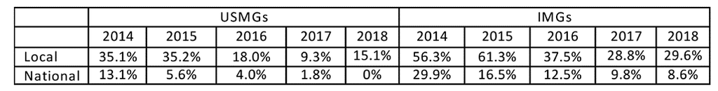

#### Percentage of Nephrology Fellows Having a Difficult Time Finding a Satisfactory Position

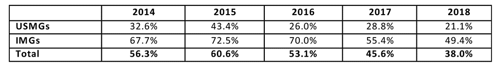

#### Changing Plans Due to Limited Practice Opportunities

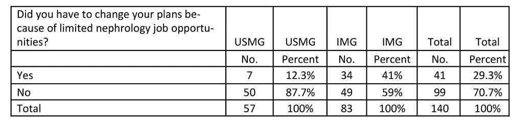

- Fellows’ anticipated salaries in 2018 were higher than in previous years; the median anticipated salary for all demographic groups (by IMG status and sex) was between $180,000 and $189,999, except for male IMGs, where the median was between $190,000 and $199,999. The mean anticipated salary was $198,000, compared to $187,000 in 2017.
- USMGs were more likely than IMGs to report being “Very satisfied” with their salary and compensation (34.7% vs. 21.3%) but the difference was not statistically significant.
- When asked to identify the incentives they had received for accepting their primary job offers, respondents were most likely to report receiving the following:
  - Income guarantees (46.9%)
  - Support for MOC and CME (40.7%)
  - Career development opportunities (38.1%)
  - Relocation allowances (38.1%)
  - Sign-on bonus (27.4%)

#### Lifestyle Concerns

Responses to a number of questions indicated the importance of lifestyle factors to fellows, both during training and for practice after training.

- Respondents in their second year of fellowship or beyond rated the following factors as “very important” or “important” in their job selection:
  - Frequency of overnight calls (94.7% very important or important)
  - Frequency of weekend duties (93.9%)
  - Length of each workday (91.7%)
  - Salary/compensation (90.9%)
  - Job/practice in desired practice setting (89.8%)
  - Job/practice in desired location (88.5%)
- This may reflect the nature of much of nephrology practice today and may be of concern to both nephrology fellows and residents who do not select the specialty.
- The final section of the report includes comments from fellows regarding why they would or would not recommend the specialty. The positive comments highlight the intellectual excitement and attraction of the specialty itself as well as long term relationships with patients. The negative comments indicate the challenges that the specialty faces. Fellows who would not recommend nephrology to medical students and residents cited the heavy workload, low compensation, difficult schedule, undervaluing of the specialty by other specialties, and lack of opportunities that support visas for IMGs as reasons for their negative assessments. This was consistent with the 2015, 2016 and 2017 responses.

## Other Findings

#### Recommending the Specialty

Despite their mixed assessments of the nephrology job market, a majority (78.8%) of fellows indicated they would recommend nephrology to current medical students and residents, a notable improvement over previous years. However, IMGs were significantly less likely than USMGs to report that they would recommend the specialty to others (75.9% vs. 83.7%, respectively).

#### Would Recommend Nephrology to Medical Students and Residents

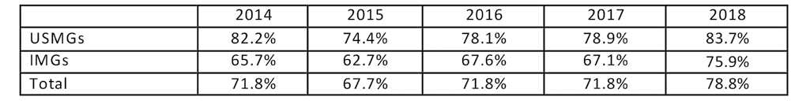

- Fellows who said they would recommend nephrology to medical students and residents cited many of the same factors mentioned by 2015, 2016 and 2017 respondents as reasons for their positive assessments: the intellectual challenge/ interest of the field, variety of activities, and long-term patient relationships.

#### Next Steps for Fellows Completing Training

- Among respondents in their second year of fellowship or beyond who indicated their plans for the upcoming year (n=239), the largest percentage planned to enter clinical nephrology practice (50.6%). One in three (33.4%) are continuing their training: 16.7% in their current fellowship and 16.7% in subspecialty training or an additional fellowship. Frequently reported areas of continuing training included research, transplant nephrology and critical care.
- Among the 2nd year respondents, USMGs were more likely to continue current fellowship (20.0% to 6.1%); IMGs were more likely to take additional subspecialty training (24.6% IMGs to 13.8% USMGs).
- It pays to go on for additional training beyond 2 years. Those going into jobs following their 3rd or 4th year of training earning on average $211,000 compared to an average of $195,000 for those going into jobs following only two years of training.

#### Practice Setting

Among respondents who had already accepted job offers, the largest group (48.3%) reported that they planned to work in nephrology group practices. Another 28.4% reported that they planned to work in academic nephrology practices, 9.5% said they planned to work in hospitals and 6.9% in multispecialty academic practices. Other settings included multispecialty group practices (3.4%) and 2-person partnerships (3.4%). No 2018 respondents reported going to work in solo practice.

#### Setting of Primary Nephrology Job

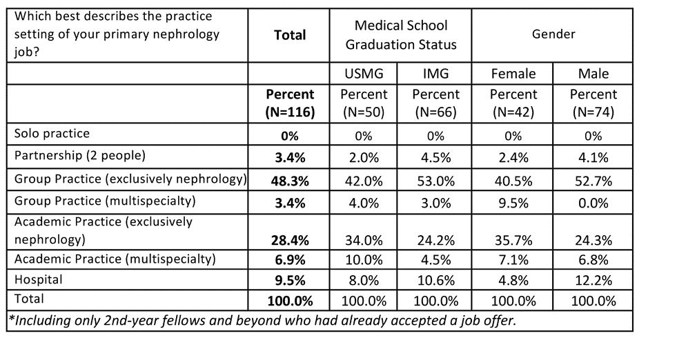

#### The Job Market

- When asked an open-ended question regarding the types of jobs they perceived to be more and less available, newly graduating fellows mentioned several types of jobs that were **more easily available** according to their experience:
  - Private practice jobs
  - Jobs in remote, rural or undesirable areas
  - Jobs in solo or small practices/communities
  - Jobs in general nephrology rather than transplant nephrology
- They reported several types of jobs that were **less easily available**:
  - Academic jobs
  - Jobs in metro areas or other preferred geographic areas
  - Jobs that meet visa requirements for IMGs

#### Compensation

As in 2017, there were some statistically significant differences between mean anticipated incomes between different practice settings.

#### Base Salary by Practice Setting of Primary Nephrology Job

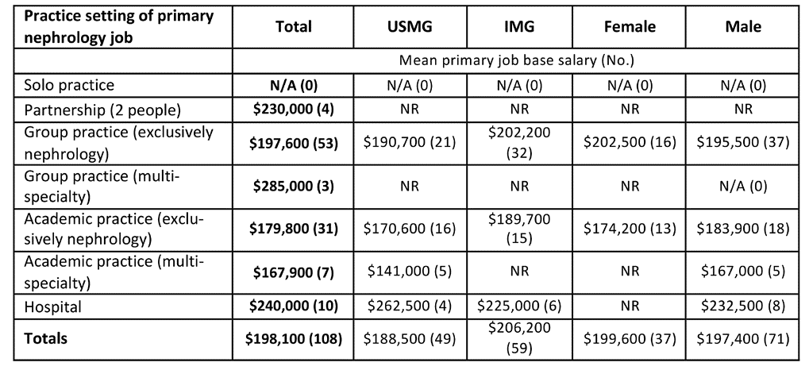

Salaries differed by population density of the geographical area of practice, with the highest average incomes in rural areas ($269,300) and small cities ($200,700), and lower incomes in suburban ($188,900), large city areas other than inner city ($196,400), and inner city ($190,300) areas. The difference between rural salaries and all others was statistically significant (p<.001). It appears rural communities need to offer nephrologists considerably more compensation than they can get in larger cities and suburban areas in order to recruit them.

#### Base Salary by Population Density of Primary Nephrology Job Location

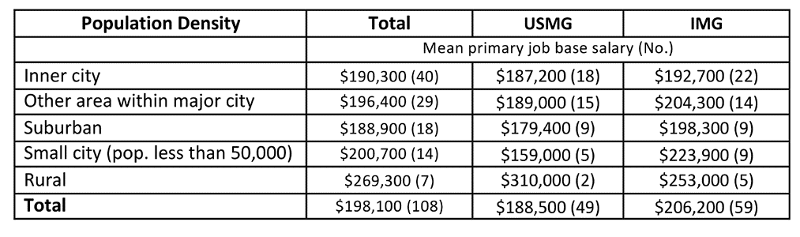

#### Job Responsibilities

The vast majority of respondents cited hospital care and outpatient nephrology care among their primary job responsibilities (98.3% and 95.7% respectively). Other responsibilities they listed included temporary dialysis catheter placement (31.9%), kidney biopsy (31.0%), medical directorship with a dialysis provider (27.6%) and clinical research (21.6%).

## Overview of Respondents

#### Exhibit 1: Respondents by Fellowship Year

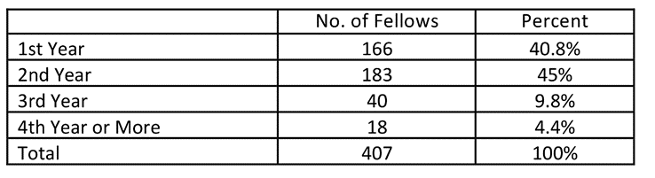

To assess the representativeness of the survey sample, we compared several demographic and educational characteristics of the 349 survey respondents in their first and second years of training to ACGME data on all 844 first- and second year- fellows (we used 2017 data as the 2018 ACGME data has not been published at the time of writing this report). Respondents in 2018 had very similar characteristics to the 2017 ACGME first- and second-year nephrology fellows, although the survey sample included slightly fewer IMGs, males and African Americans and slightly more Hispanic/Latino respondents. The percentage of African American survey respondents in their first and second years of training was lower in 2018 than in 2017—6.6% vs. 7.7%; the percentage of Hispanic/Latino survey respondents was higher than in 2016 (10.6% compared to 8.9%).

#### Exhibit 2: Comparison of 1st- and 2nd-Year Fellow Survey Respondents with ACGME Data

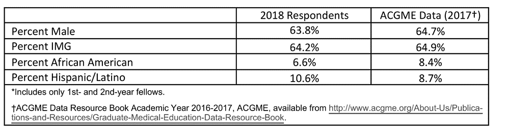

## Education, Citizenship Status, and Demographics of Respondents

This section presents data on the educational background, citizenship status, and demographics of all respondents to the 2018 Nephrology Fellow Survey.

#### Location of Medical School

#### Exhibit 3: Medical School

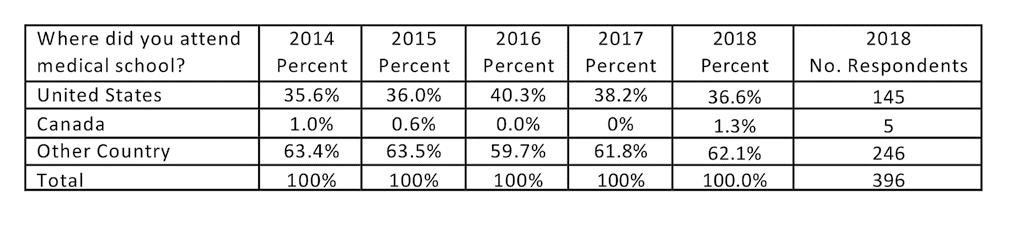

As in previous years, most 2018 survey respondents (62.1%) attended medical school outside the United States. These IMG respondents reported attending medical school in 50 different countries, the most frequently cited of which were India (58 respondents); Pakistan (32 respondents); Dominica (11 respondents); Jordan, Nepal and Syria (9 respondents each); China and Egypt (8 respondents each); Grenada and Iraq (7 respondents each); Dominican Republic, Japan and Mexico (6 each); and Lebanon and Nigeria (5 each).

#### Exhibit 4: Citizenship Status

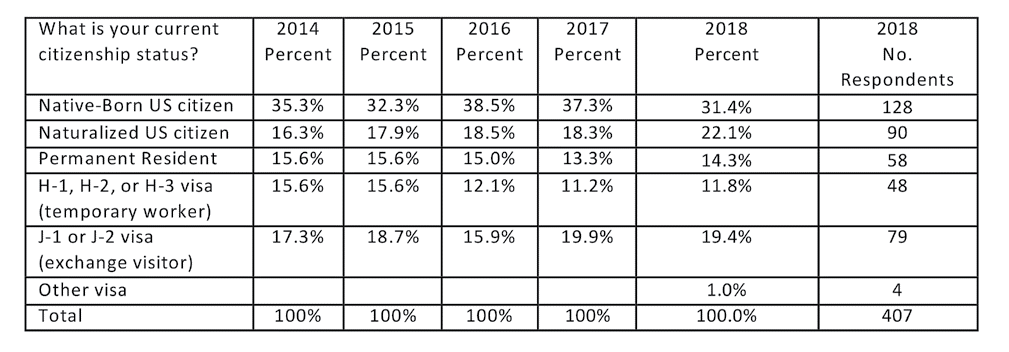

The distribution of 2018 survey respondents’ citizenship status was also similar to that of previous years’ respondents. More than half of 2018 respondents (53.5%) reported that they were US citizens, either native born or naturalized, and 14.3% reported that they were permanent residents of the United States. About 32.2% of the respondents were non- citizen holders of H, J or other visas (a slightly higher percentage than in earlier years).

As in previous years, we identified a number of respondents who could be considered US IMGs, that is, US citizens who received their medical education outside the US. Native-born US citizen IMGs represented 9.6% of all respondents indicating they had received their medical education in another country in 2018 with naturalized U.S. citizen IMGs adding a further 20.3%.

#### Sex

#### Exhibit 5: Sex of 2018 Respondents

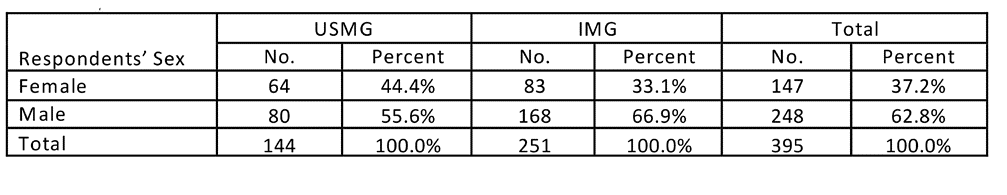

As in previous years, the majority of 2018 survey respondents (62.8%) were male—a larger percentage than in 2016 (61.1%). The difference in gender balance between IMGs (66.9% male) and USMGs (55.6% male) was statistically significant (p=0.024), unlike in 2016 and 2017 when the difference was not significant.

#### Age

#### Exhibit 6: Age of 2018 Respondents

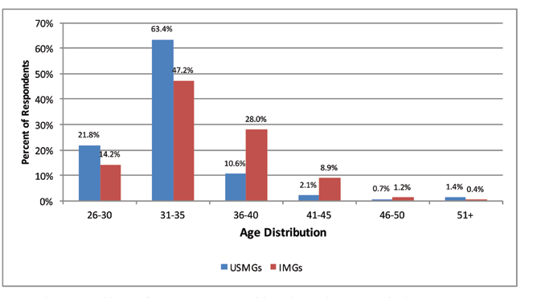

Respondents ranged in age from 27 to 54 years old. As in previous years, the largest age group was 31 to 35 years, which included more than one-half of respondents. Also, as in 2017, IMG respondents were significantly older on average than USMG respondents on average (34.9 years vs. 32.9 years—p<0.001).

#### Race/Ethnicity

#### Exhibit 7: Race of 2018 Respondents

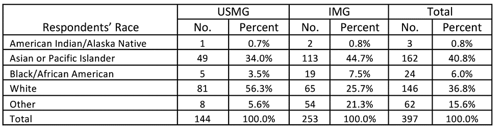

When asked to identify their race, the largest group of respondents identified themselves as Asian (40.8%), and the next largest group (36.8% of respondents) identified themselves as white. The distribution of race/ethnicity was significantly different across IMG categories: IMGs were significantly more likely to report being Asian (p<0.05, effect size=0.23) or of “other” race (p<0.01, effect size=0.45) than USMGs, and USMGs were significantly more likely to report being white than IMGs (p<0.01, effect size=0.65). The proportions of respondents who reported that they were black were not significantly different between the USMG and IMG groups (p=.098).

#### Exhibit 8: Ethnicity of 2018 Respondents

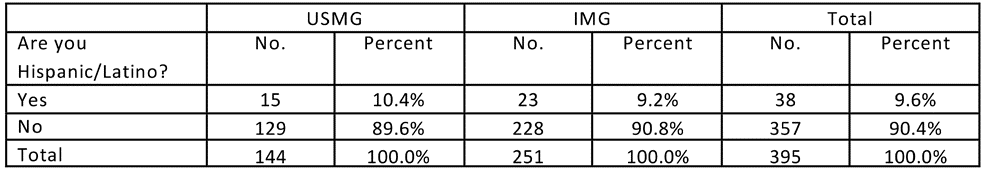

9.6% of all respondents identified themselves as Hispanic or Latino, more than the 8.2% of 2016. This is more than the 8.7% of ACGME nephrology residents and fellows who are Hispanic/Latino; however, because nephrology is accredited as a two-year program ACGME only capture 1st and 2nd year fellows (ACGME, Annual Resource Data Book, 2016-17). IMG respondents were less likely to identify themselves as Hispanic or Latino than USMG respondents, but the difference was not statistically significant (p=0.684).

#### Educational Debt

#### Exhibit 9: Educational Debt

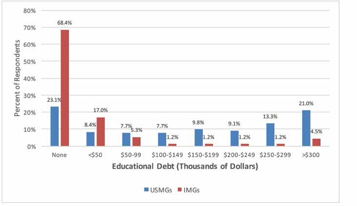

Respondents’ reported levels of educational debt varied from no debt to greater than $300,000. As in previous years, IMGs were much less likely to be in debt than USMGs: 68.4% of IMG respondents reported having no educational debt compared with only 23.1% of USMGs (p<0.001, effect size = 0.84). (Effect sizes are typically classified as 0.2 = low, 0.5 = medium, 0.8 = large; the measure of effect size used throughout is Cohen’s d.) An additional 17.0% of IMGs reported educational debt levels <$50,000. USMG respondents were more likely than IMGs to report debt levels in every debt tier beyond $50,000. More than 1 in 5 (21.0%) of USMG respondents and 4.5% of IMG respondents reported having >$300,000 of educational debt, compared to 2017 when the comparable figures were 17.2% and 6.5% respectively. IMG respondents had a median educational debt of $0, while USMG respondents had a median educational debt of between $150,000 and $174,999, the same as in 2017 but still higher than in any of the previous survey years.

## Post-Training Plans (2nd-Year and Beyond Fellows Only)

#### Activity After Completion of Current Training Year

#### Exhibit 10: Activity After Completion of Current Training Year

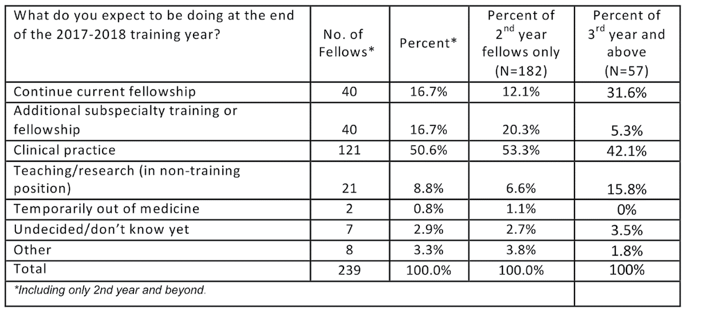

Among respondents in their second year of fellowship or beyond who indicated their plans for the upcoming year (n=239), the largest percentage planned to enter clinical nephrology practice (50.6%). One in three (33.4%) are continuing their training: 16.7% in their current fellowship and 16.7% in subspecialty training or an additional fellowship.

#### Exhibit 11: Type of Continuing Training Pursued by Fellows

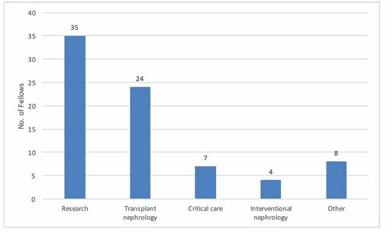

USMGs were significantly more likely than IMGs to report that they planned to continue their current fellowships (23.5% vs. 12.1%, p<.05, effect size = 0.31) while IMGs were more likely than USMGs to be planning additional subspecialty training or fellowship (21.5% vs. 10.3%, p<.05, effect size=0.30). We found no other significant differences in the distribution of anticipated activities between USMG and IMG fellows. The patterns were similar among 2nd year respondents only, with USMGs more likely to be continuing current fellowship (20.0% to 6.1%) and IMGs more likely to be taking additional subspecialty training (24.6% to 13.8%).

We found no significant differences in the distribution of anticipated activities between male and female fellows. Females were more likely than males to be temporarily out of medicine (1.43% vs. 0%) but this difference was not statistically significant (p=.13).

#### Job Selection

Respondents in their second year of fellowship or beyond rated the following factors as very important or important in their job selection:

- Frequency of overnight calls (94.7% very important or important)
- Frequency of weekend duties (93.9%)
- Length of each workday (91.7%)
- Salary/compensation (90.9%)
- Job/practice in in desired practice setting (89.8%)
- Job/practice in desired location (88.5%)

They rated the following factors as least important:

- Taxes (52.9%)
- Cost of malpractice insurance (50.5%)
- Cost of setting up a medical practice (44.0%)
- Job/practice meets visa requirements (36.4%)
- Availability of part-time position (27.4%)

#### Factors Influencing Job Selection

#### Exhibit 12: Factors Influencing Job Selection

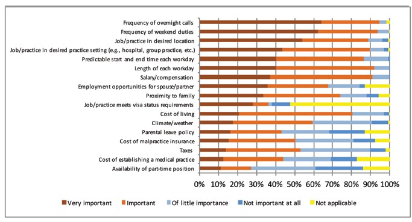

USMGs and IMGs differed significantly when rating the following factors (in order of effect size):

- Job/practice meets visa requirements (IMGs more likely than USMGs to rate as very important, p<0.001, effect size = 1.1)
- Predictable start time (IMGs more likely to rate as very important, p<.01, effect size=0.41)
- Workday length (IMGs more likely to rate as very important, p<.01, effect size=0.40)
- Salary/compensation (IMGs more likely than USMGs to rate as very important, p=0.01, effect size=0.37)
- Climate (USMGs more likely to rate as very important, p<.05, effect size=0.35)
- Part-time availability (USMGs more likely to rate as very important, p<.05, effect size=0.33)
- Parental leave policy (IMGs more likely to rate as very important, p<.05, effect size=0.33
- Weekend duties (IMGs more likely to rate as very important, p<.05, effect size=0.28)

USMG and IMG fellows’ ratings of other factors were not significantly different. Male and female fellows differed significantly when rating the following factor:

- Parental leave policy (female fellows more likely than male fellows to rate as very important, p<0.001, effect size=0.69)

Male and female fellows’ ratings of other factors were not significantly different.

## Job Market Experiences and Perceptions

This section reports on the experiences of the 143 nephrology fellows who had searched for employment. As in previous years, the job market was more challenging for IMG fellows who were more likely than USMG fellows to apply for large numbers of jobs, have difficulty finding a satisfactory position, and change plans because of limited opportunities. Nevertheless, signs of continued improvement in the job market included fewer job applications, fewer people receiving no job offers, fewer IMGs reporting difficult finding a satisfactory position and fewer people reporting lack of jobs in both local and national job markets. Although these trends have continued for several years now and provide some cause for future optimism, there is a continuing sense that many fellows are unable to find the kind of jobs they would have preferred.

#### Number of Job Applications

Among fellows who had searched for a job, 67.6% reported applying for between 1 and 5 jobs, and 28.2% reported that they had applied for at least 6 jobs (including 9.9% who applied for more than 10 jobs). A few fellows (4.2%) reported that they had not applied for any jobs.

We found a statistically significant difference in the number of job applications between IMG and USMG fellows (p=0.030): IMGs were more likely than USMGs to apply for more than 10 jobs (14.5% of IMGs vs. 1.8% of USMGs), and USMGs were more likely than IMGs to apply for 1 to 5 jobs (82.5% vs. 57.8%). The percentage of USMGs who reported that they applied for 6 or more positions continued its steady decline declined from 43.5% in 2015 and 22.1% in 2017 to 14.1% in 2018. The percentage of IMGs who reported applying for 6 or more jobs similarly continued its decline from 63.3% in 2015 and 40.6% in 2017 to 37.4% in 2018.

We found no statistically significant differences existed in the number of job applications between male and female fellows (p=0.97).

#### Number of Job Offers

The majority of nephrology fellows (68.8%) reported receiving between 1 and 3 job offers. A small number of fellows reported receiving more than 10 job offers (1.4%), and 4.3% of fellows reported receiving no job offers. The percentage of USMGs who reported receiving no job offers (1.8%) was similar to 2017 (1.7%) but lower than in 2016 (4.0%) and 2015 (3.8%).

USMGs were more likely to report receiving 1 to 3 job offers (80.4% vs. 61.4%), and IMGs were more likely to report receiving no job offers (4.8% vs. 1.8%) but also more likely to report receiving 4 offers or more (33.7% vs. 17.9%). The differences were not statistically significant. We found no statistically significant differences in the number of job offers between male and female fellows (p=0.95).

#### Difficulty Finding a Satisfactory Position

We found no statistically significant difference in reports of difficulty finding a position between male and female fellows (p=0.81).

#### Exhibit 13: Percentage of Nephrology Fellows Having a Difficult Time Finding a Satisfactory Position

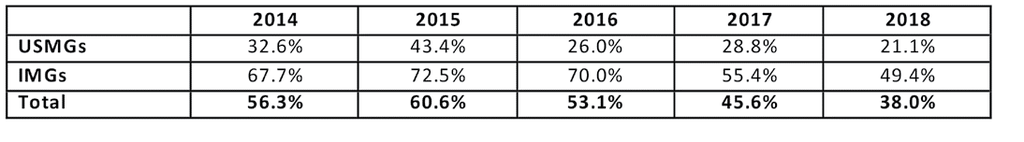

#### Reasons for Difficulty

Among the fellows who reported difficulty finding a satisfactory position, the top 3 most frequently cited reasons were consistent from 2017 to 2018 though with a change in order (Exhibit 14). The reasons most frequently cited by 2018 fellows were inadequate salary/compensation (34% vs. 21.9% in 2017), lack of jobs/practice opportunities in desired locations (24.5% of those reporting any difficulty vs. 31.5% in 2017) and lack of jobs/practice opportunities that meet visa status requirements (22.6% vs. 16.4% in 2017).

#### Exhibit 14: Reasons for Difficulty

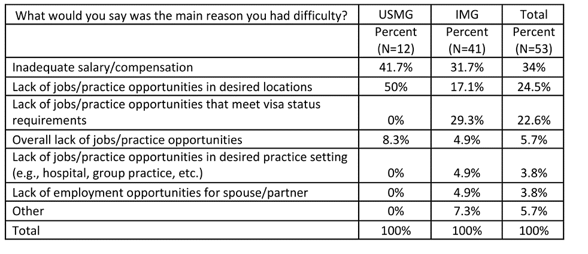

We found no statistically significant difference in the reasons for difficulty finding a position between male and female fellows (p=0.818 for any difficulty).

#### Exhibit 15: Changing Plans Due to Limited Practice Opportunities

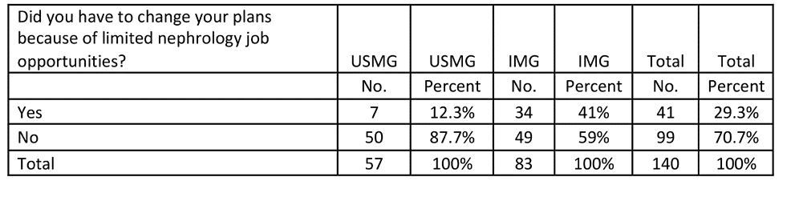

We found no statistically significant differences in male and female fellows’ likelihood of changing their plans (p=0.41).

#### Job Market Perceptions

Survey respondents were asked to indicate their perceptions of the local job market (within 50 miles of where they trained) and the national job market. Response options ranged from no jobs to many jobs. Key findings include:

#### Local Job Market Perceptions

Among nephrology fellows who had searched for jobs, perceptions of local nephrology job opportunities continued to improve: while 37.7% reported in 2016 that there were many or some nephrology practice opportunities within 50 miles of their training sites, and 41.5% did so in 2017, the proportion reporting the same in 2018 increased to 51.1%.

We found a statistically significant difference in IMG and USMG fellows’ assessments of local nephrology practice opportunities with USMGs more likely than IMGs to report that there were many or some job opportunities in their local area (62.4% vs. 46.1%, p<0.01, effect size=0.60).

We found no statistically significant differences in local job market perceptions between male and female fellows (p=0.50).

#### Exhibit 16: Percentage of Nephrology Fellows Responding “No Jobs” or “Very Few Jobs”

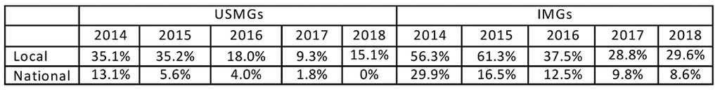

#### National Job Market Perceptions

As in 2017 we found a statistically significant difference in IMG and USMG fellows’ assessments of national nephrology practice opportunities, with USMGs more likely than IMGs to report that there were many or some job opportunities nationally (92.0% vs. 80.7%, p<0.01, effect size=0.62).

We found no statistically significant difference between male and female fellows’ assessments of national nephrology practice opportunities (p=0.36).

#### Types of Jobs Available

When we asked fellows to indicate in an open-ended question what types of jobs they perceived to be more and less available for newly graduating fellows, they mentioned several types of jobs that were more easily available according to their experience:

- Private practice jobs
- Jobs in remote, rural or undesirable areas
- Jobs in solo or small practices/communities
- Jobs in general nephrology rather than transplant nephrology

They also mentioned several types of jobs that were less easily available according to their experience:

- Academic jobs
- Jobs in metro areas or other preferred geographic areas
- Jobs that meet visa requirements for IMGs

These lists were almost identical to the 2017 lists. As in 2017, a small number of respondents mentioned limited availability of hospital jobs and private practice positions, with the problem more acute when combined with one of the other categories of shortfall such as urban situation.

## Job Offer Characteristics

Among the 118 nephrology fellows who had already accepted job offers, we found the following with respect to their salary and compensation expectations.

#### Practice Setting

Among respondents who had already accepted job offers, the largest group (48.3%) reported that they planned to work in nephrology group practices (Exhibit 17). Another 28.4% reported that they planned to work in academic nephrology practices, 9.5% said they planned to work in hospitals and 6.9% in multispecialty academic practices. Other settings included multispecialty group practices (3.4%) and 2-person partnerships (3.4%). No 2018 respondents reported going to work in solo practice.

#### Exhibit 17: Setting of Primary Nephrology Job

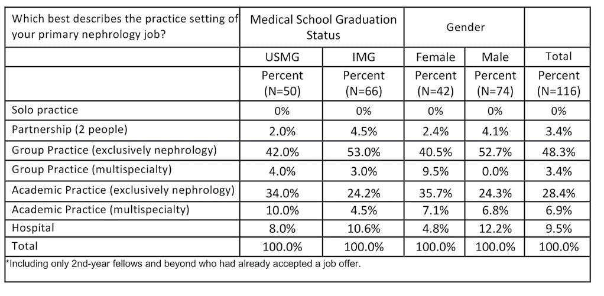

None of the differences between USMGs and IMGs in setting distribution reached statistical significance. Female fellows were more likely to report that they planned to work in academic nephrology (35.7% vs. 24.3%) and multispecialty group practices (9.5% vs. 0%); male fellows were more likely to report that they planned to work in nephrology group practices (52.7% vs. 40.5%), 2-person partnerships (4.1% vs. 2.4%) and hospitals (12.2% vs. 4.8%). However, the only one of these differences that was statistically significant was the gender difference for working in multispecialty group practices (p<.01, effect size=0.53).

#### Location of Practice

#### Exhibit 18: Location of Primary Nephrology Job (Demographics)

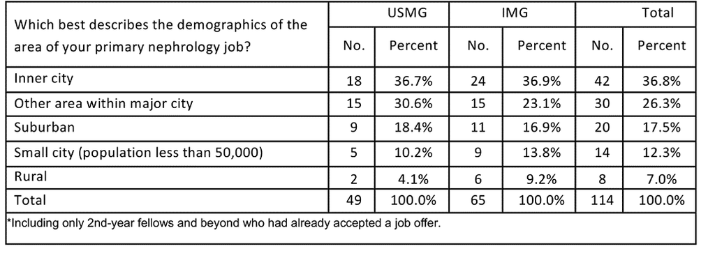

Among respondents with job offers, the majority (63.1%) indicated that they planned to work in urban areas (inner city or other). Another 17.5% said they planned to work in suburban areas, and 12.3% said they planned to work in small cities. Similar to 2017, when 9 fellows (7.8% of respondents) reported intending to work in a rural area, in 2018 there were 8 fellows (7.0% of respondents) reporting intending to work in a rural area.

USMGs were more likely to report intending to work in other urban areas (30.6% vs. 23.1%) and suburban areas (18.4% vs. 16.9%) while IMGs were more likely to report intending to work in small cities (13.8% vs. 10.2%) and rural areas (9.2% vs. 4.1%). USMGs and IMGs were equally likely to report intending to work in inner cities (36.7% vs. 36.9%). Unlike in 2017, none of the differences between USMGs and IMG fellows were statistically significant.

We found no statistically significant differences between male and female fellows’ anticipated practice locations (p=0.36).

#### Obligations to Practice in Underserved Areas

#### Exhibit 19: Service Obligation

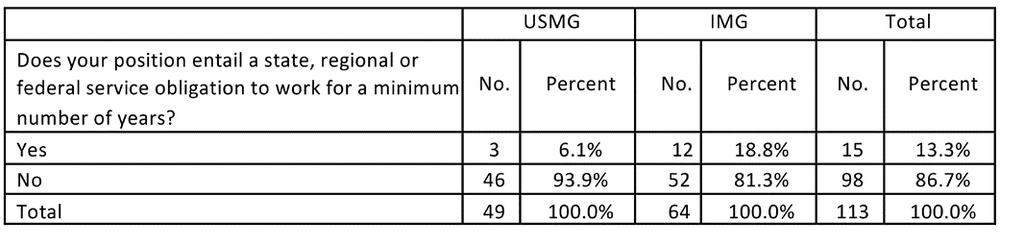

A total of 15 respondents had accepted jobs that came with a service obligation period. IMGs were more likely than USMGs to accept a job that entailed a minimum service obligation period (18.8% vs. 6.1%). The difference in the distribution of service obligations by IMG status was almost significant (p<0.056).

There was little difference between females and males in the proportion accepting a minimum service obligation (15.4% vs. 12.2%).

#### Exhibit 20: Reason for Service Obligation

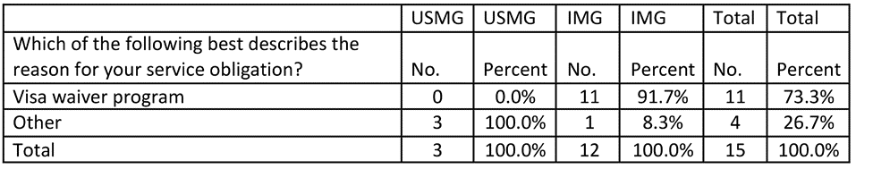

Of the 15 service obligation positions reported, 11 (73.3%) were J visa waiver positions, 10 of them under the Conrad State 30 program and the other under the Delta Regional Authority’s program. Of these 11 positions, 10 were for positions based in Health Professional Shortage Areas (HPSA); the other was for service in a rural area. All of the waiver positions were held by IMGs.

The other four positions were obligations under T32 and TL1 training grants from NIH (one each), one with the U.S. Army and the other an unspecified income guarantee program. Three of the four non-waiver positions were held by US-born USMGs, with the remaining position held by an IMG who was nevertheless a native-born US citizen.

All respondents who were not U.S. citizens or permanent residents were asked about their interest in the physician National Interest Waiver, which permits those holding temporary worker visas to apply for U.S. permanent residency after five years of service in a designated shortage area. More than half (54.5%) expressed interest, with only 15.4% definitely not interested.

We found no statistically significant differences between male and female fellows’ anticipated practice locations (p=0.36).

#### Exhibit 21: Interest in Physician National Interest Waiver

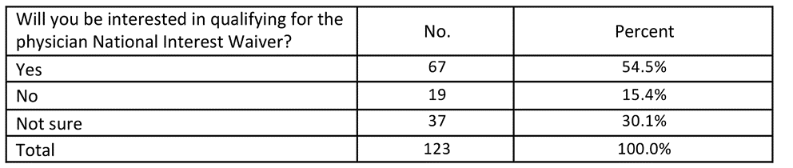

#### Base Salary/Income

Among the fellows who had accepted job offers, the range of expected salaries was from <$80,000 to $329,999. More than three out of five (62.0%) anticipated annual base salaries between $140,000 and $209,999.

Male IMGs had the highest median expected base salaries of all demographic groups by IMG status and gender, in the range $190,000– $199,999. Female USMGs and IMGs and Male USMGs all had median expected base salaries in the range $180,000– $189,999.

In contrast to the position with USMGs, female IMGs had a $15,000 lower average expected base salaries than male IMGs (though this difference was not statistically significant, p=0.34), and also a lower median income (in the $180,000- $189,999 range vs. $190,000- $199,999 range for males). IMGs overall had an almost $18,000 higher average expected base salaries than USMGs, a difference that, as in 2017, was almost statistically significant in a one-sided t-test (p=.051), and also a higher median income (in the $190,000- $19,999 range vs. $180,000- $189,999 range for USMGs).

(Because survey respondents were only asked to report their salaries within $10,000 ranges, the calculation of mean values set out in Exhibit 22 relies on the assumption that actual salaries were evenly distributed within each salary range, which cannot be guaranteed.)

Somewhat surprising, male USMGs were making considerably less than male IMGs and female USMGs (male USMGs: $181,000; male IMGs: $211,600; female US MGs: $203,800). Given the small sample size in each category, it is difficult to identify the key factors leading to these differences. In regard to male USMGs and IMGs, it appears that male USMGs are more likely to work in academia than male IMGs (39.4% vs. 24.4%). Male IMGs also report spending more time on patient care relative to male USMGs (27.5% work 60 or more hours per week on patient care vs. 6.1%) while male USMGs report spending more time on teaching and research. Interestingly, IMGs report a more difficult time finding a satisfactory position, and rate salary as more important than USMGs despite having far less debt than IMGs.